# Tema 11: Distribuciones

Alonso Pizarro Lagunas

8/12/2021

# Distribuciones en *R* y *Python*

Algunas funciones de *R* para cualquier variable aleatoria $v.a$

- `dva(x, ...)` se refiere a la función de densidad o probabilidad $f(x)$ de la $v.a$
- `pva(x, ...)` se refiere a la funcion de distribución $F(x)$ de la $v.a$
- `qva(p, ...)` Cuantil $p$-ésimo de la $v.a$ (el valor de x más pequeño tal que $F(x) \ge p$)
- `rva(n, ...)` Generador de n observaciones siguiendo la distribución de la $v.a$

En `va` debemos indicar la distribución. Por ejemplo si es una Bernoulli indicamos `dbern`, `pbern`, `qbern` y `rbern`. Para una normal `dnorm`, `pnorm`, `qnorm` y `rnorm`. Así, con todas las distribuciones.

Algunas funciones de *Python* para cualquier variable aleatoria $v.a$

- `pmf(k, ...)` o `pdf(x, ...)` se refiere a la función de densidad ($f(x)$) o probabilidad $f(k)$ de la $v.a$
- `cdf(x, ...)` se refiere a la funcion de distribución $F(x)$ de la $v.a$
- `ppf(p, ...)` Cuantil $p$-ésimo de la $v.a$ (el valor de x más pequeño tal que $F(x) \ge p$)
- `rvs(size, ...)` Generador de *size* observaciones siguiendo la distribución de la $v.a$

## Distribución de Bernoulli

Si $X$ es una $v.a$ que mide el número de éxitos (fracasos) y se realiza un único experimento diremos que $X$ se distribuye como una Bernoulli con parámetro $p$
$$X \sim Be(p)$$
donde $q = 1-p$ es la probabilidad de fracaso.

- El *dominio* de $X$ es $X(\Omega)= \{0,1\}$
- La *función de probabilidad* es
  $$f(k)=p^k\cdot (1-p)^{1-k}$$
- La *función de distribución* es

$$F(k)=\left\{ \begin{array}{ll}
0 & \mbox{si $k<0$} \\
q & \mbox{si $0\le k <1$} \\
1 & \mbox{si $k\ge1$}
\end{array}
\right.$$

- Con *Esperanza* $E(X)= p$ y *Varianza* $Var(X) = pq$

### Un ejemplo con la distribución Bernoulli en R

Sea $X \sim Be(p =0.7)$, la distribución que modela la probabilidad de obtener una cara usando una moneda trucada.

```r
library(Rlab) # Recordamos cargar el paquete Rlab que contiene toda la info sobre distribuciones
dbern(0, prob = 0.7) # Prob de sacar 0, f`n densidad
```

```
## [1] 0.3
```

```r
dbern(1, prob = 0.7) # Prob de sacar 1, f`n densidad
```

```
## [1] 0.7
```

```r
pbern(0, prob = 0.7) # F`n acumulada
```

```
## [1] 0.3
```

```r
pbern(1, prob = 0.7) # F`n acumulada
```

```
## [1] 1
```

```r
qbern(0.5, prob = 0.7) # segundo cuartil
```

```
## [1] 1
```

```r
qbern(0.25, prob = 0.7) # primer cuartil
```

```
## [1] 0
```

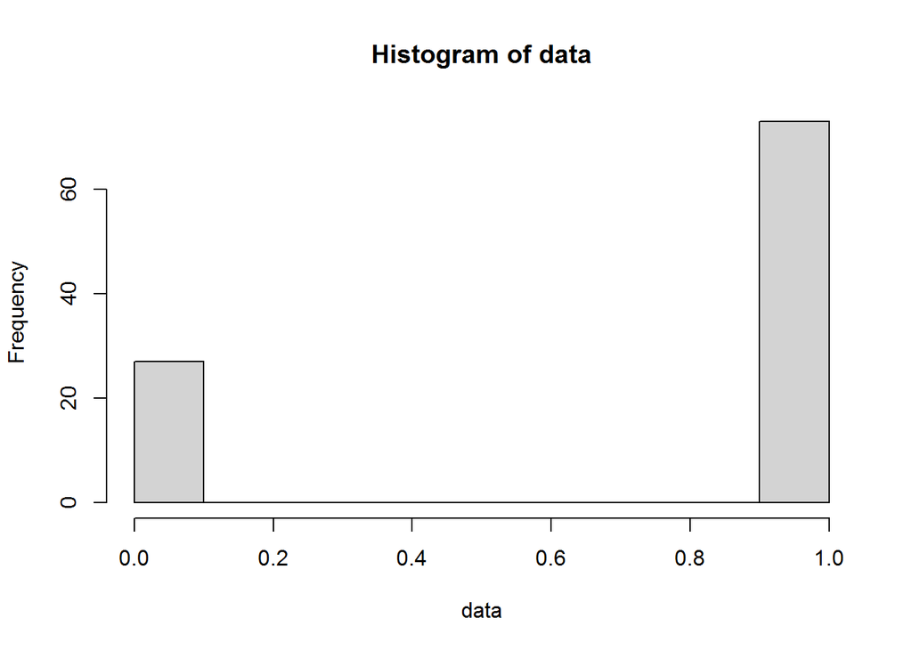

```r
data <- rbern(100, prob = 0.7) # Generemos 100 números aleatorios con esta distribución
hist(data) # Visualizamos los datos en un histograma
```

### Un ejemplo con la distribución Bernoulli en Python

```python
from scipy.stats import bernoulli
import matplotlib.pyplot as plt
p = 0.7
mean, var, skew, kurt = bernoulli.stats(p, moments = 'mvsk')
print("Media %f"%mean)
```

```
## Media 0.700000
```

```python
print("Varianza %f"%var)
```

```
## Varianza 0.210000
```

```python
print("Sesgo %f"%skew)
```

```
## Sesgo -0.872872
```

```python
print("Curtosis %f"%kurt)
```

```
## Curtosis -1.238095
```

```python
fix, ax = plt.subplots(1,1)
x = bernoulli.rvs(p,size=1000)
ax.hist(x)
```

```
## (array([295.,   0.,   0.,   0.,   0.,   0.,   0.,   0.,   0., 705.]), array([0. , 0.1, 0.2, 0.3, 0.4, 0.5, 0.6, 0.7, 0.8, 0.9, 1. ]), <BarContainer object of 10 artists>)
```

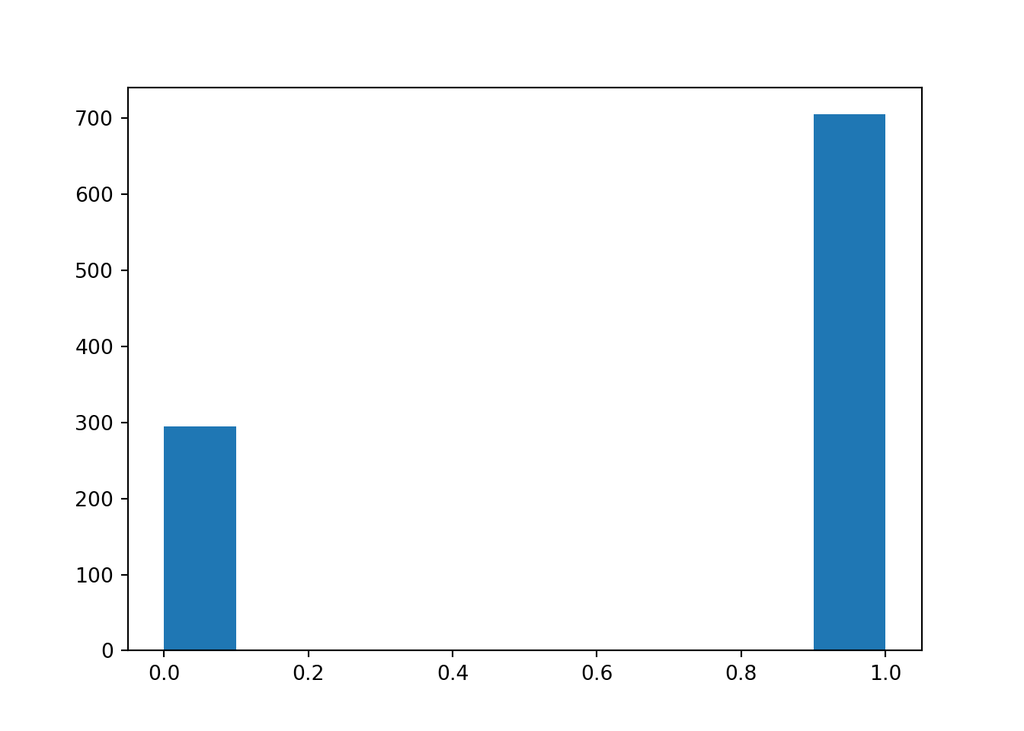

```python
plt.show()
```

## Distribución Binomial

Si $X$ es una $v.a$ que mide el número de éxitos y se realizan n ensayos Bernoulli independientes entre sí diremos que $X$ se distribuye como una binomial con parámetros n y p
$$X \sim B(n,p)$$
donde p es la probabilidad de éxito y $q=1-p$ es la probabilidad de fracaso.

- El *dominio* de $X$ será $D_{X} = \{0,1,2,...,n\}$
- La *función de densidad* viene dada por
  $$f(k) = {n \choose k} p^k (1-p)^{n-k}$$
- La *función de distribución* viene dado por
  $$F(x)=\left\{ \begin{array}{ll}
  0 & \mbox{si $x<0$} \\
  \sum_x^{k=0}f(k) & \mbox{si $0\le x <1$} \\
  1 & \mbox{si $x \ge n$}
  \end{array}
  \right.$$
- Con una *Esperanza* igual a $E(X)=np$ y una *Varianza* igual a $Var(X) = npq$.

### Un ejemplo de la distribución binomial en R.

Sea $X \sim B(n = 30, p = 0.6)$

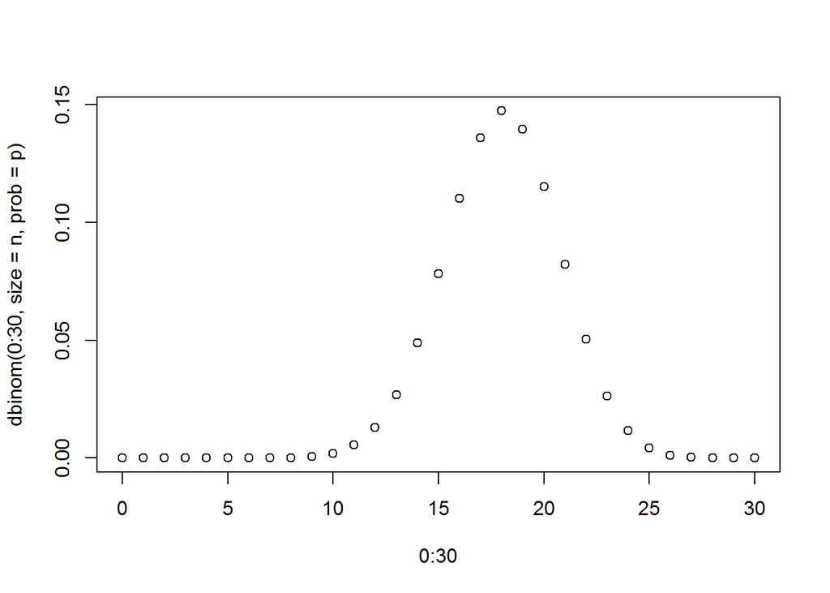

```r
n =30
p =0.6
plot(0:30,dbinom(0:30, size = n, prob =p))
```

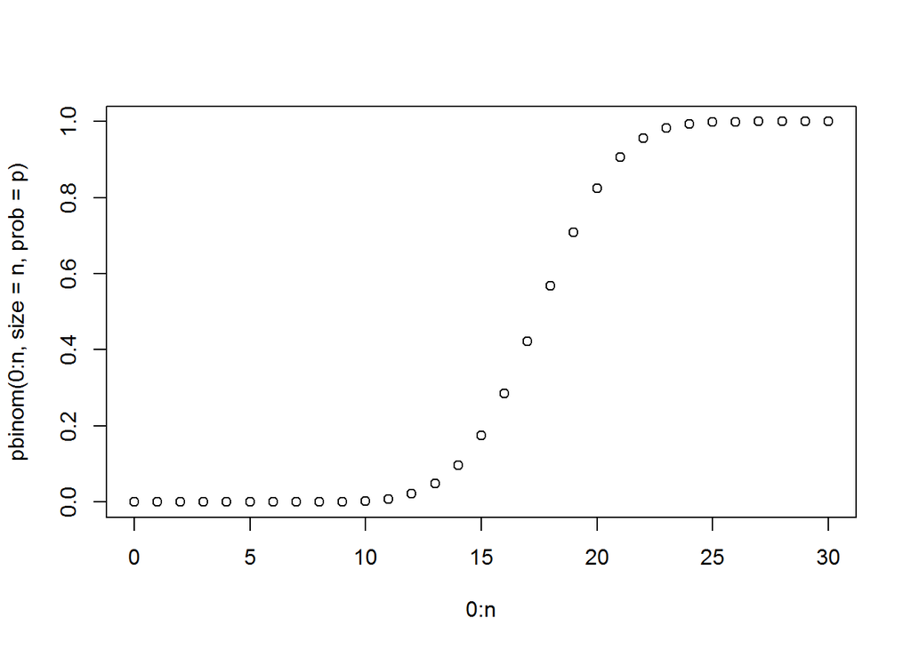

```r
plot(0:n, pbinom(0:n, size = n, prob = p))
```

```r
qbinom(0.5, n, p)
```

```
## [1] 18
```

```r
qbinom(0.25, n, p)
```

```
## [1] 16
```

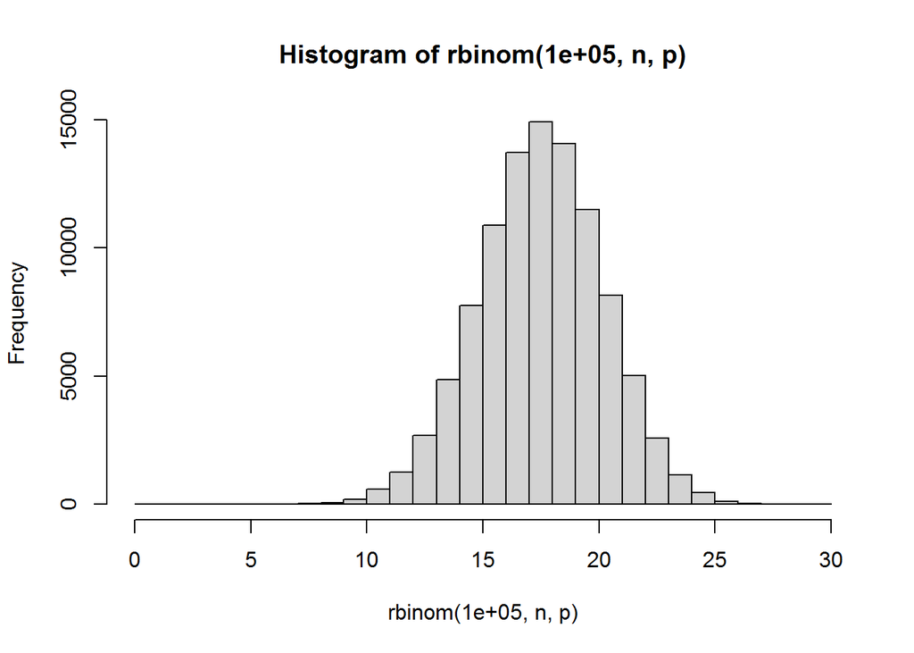

```r
hist(rbinom(100000, n, p), breaks =0:30)
```

### Un ejemplo de la distribución binomial en Pyhton.

```python
from scipy.stats import binom
import matplotlib.pyplot as plt
import numpy as np

fig, ax = plt.subplots()
n = 7
p = 0.4

mean, var, skew, kurt = binom.stats(n, p, moments = 'mvsk')
print("Media %f"%mean)
```

```
## Media 2.800000
```

```python
print("Varianza %f"%var)
```

```
## Varianza 1.680000
```

```python
print("Sesgo %f"%skew)
```

```
## Sesgo 0.154303
```

```python
print("Curtosis %f"%kurt)
```

```
## Curtosis -0.261905
```

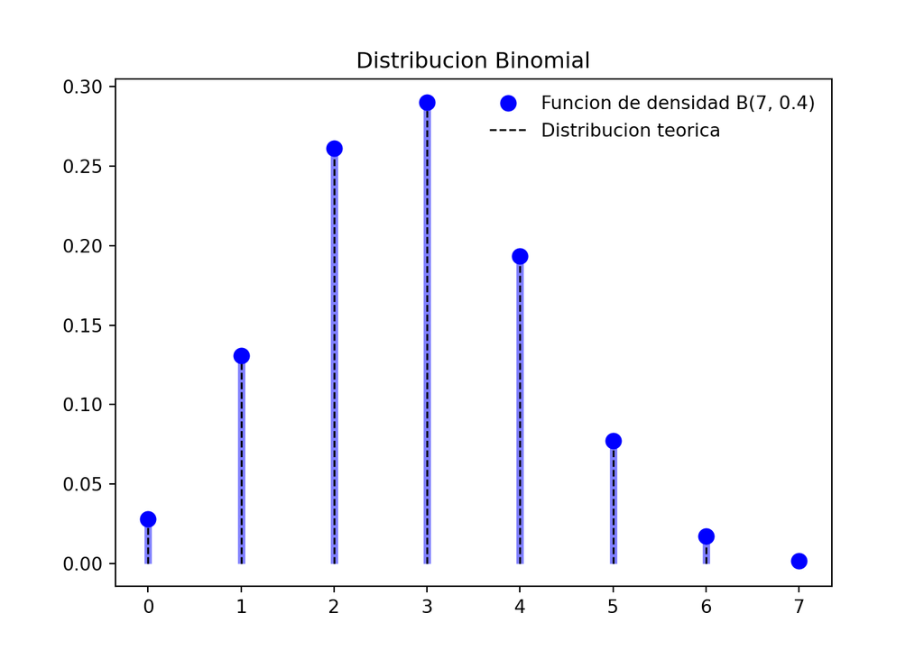

```python
x = np.arange(0,n+1)
ax.plot(x, binom.pmf(x,n,p),'bo',ms = 8, label = 'Funcion de densidad B(7, 0.4)')
ax.vlines(x, 0, binom.pmf(x,n,p), colors = 'b', lw = 4, alpha = 0.5)

rv = binom(n,p)
ax.vlines(x,0, rv.pmf(x), colors ='k', linestyles = '--', lw = 1, label ='Distribucion teorica')
ax.legend(loc = 'best', frameon = False)
ax.set_title(r'Distribucion Binomial')
plt.show()
```

```python
fig, ax = plt.subplots(1,1)
r = binom.rvs(n,p, size = 1000)
ax.hist(r, bins = n)
```

```
## (array([ 31., 130., 266., 317., 173.,  63.,  20.]), array([0., 1., 2., 3., 4., 5., 6., 7.]), <BarContainer object of 7 artists>)
```

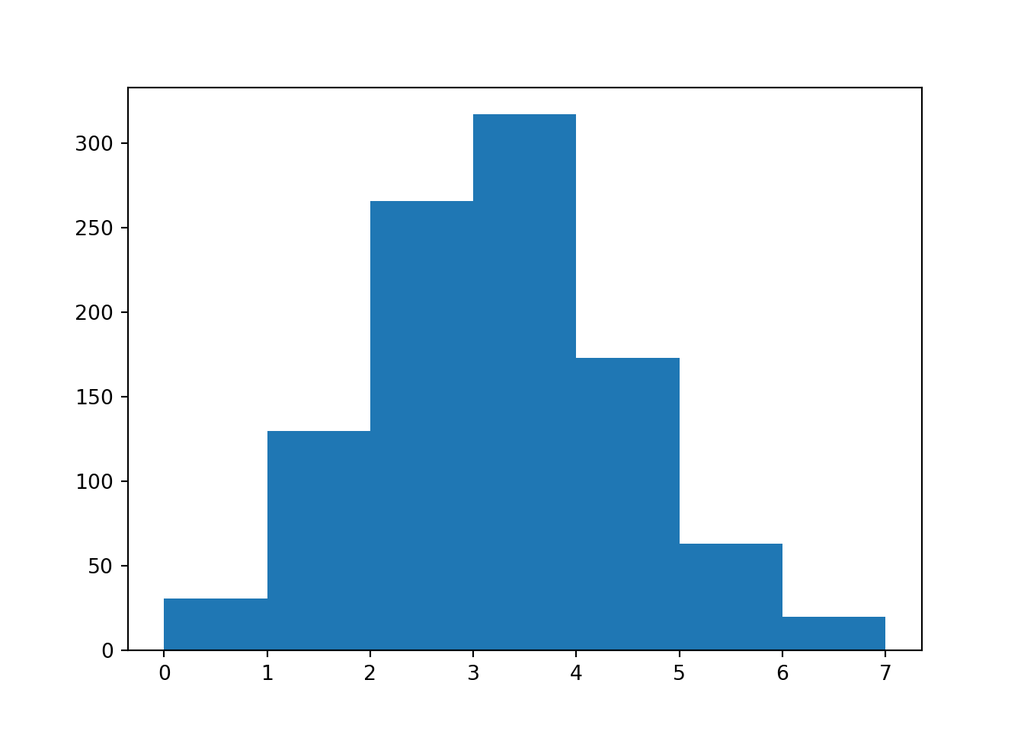

```python
plt.show()
```

Podemos encontrar más información sobre la visualización en la página de [Matplotlib](https://matplotlib.org/stable/gallery/lines_bars_and_markers/fill_between_alpha.html#sphx-glr-gallery-lines-bars-and-markers-fill-between-alpha-py) y más.

## Distribución Geométrica

Sea $X$ una $v.a$ que mide el número de repeticiones independientes del experimento hasta haber conseguido un éxito diremos que $X$ se distribuye como una Geométrica con parámetro $p$
$$X \sim Ge(p)$$
donde $p$ es la probabilidad de éxito y $q = 1-p$ es la probabilidad de fracaso.

- El *dominio* de $X$ es $D_X=\{0,1,2, ... \}$ o bien $D_X = \{1,2,...\}$ si comienza con cero o comienza en uno.
- La *función de densidad* viene dada por
  $$f(k)=(1-p)^k$$
  si comienza en cero o
  $$f(k)=(1-p)^{k-1}\cdot p$$
  si comienza con 1.
- La *función de distribución* viene dado por
  $$F(x)=\left\{ \begin{array}{ll}
  0 & \mbox{si $x<0$} \\
  1-(1-p)^{k+1} & \mbox{si $k\le x <k+1, k \in \mathbb{N}$}
  \end{array}
  \right.$$
- La *esperanza* $E(X) = \frac{1-p}{p}$ si comienza en 0 y $E(X)=\frac{1}{p}$ si es uno.
- La *varianza* es $Var(x) = \frac{1-p}{p^2}$.

### Un ejemplo en R

Sea $X \sim Ge(p = 0.1)$ las distribución que modela la probabilidad de abrir una puerta hasta conseguirlo.

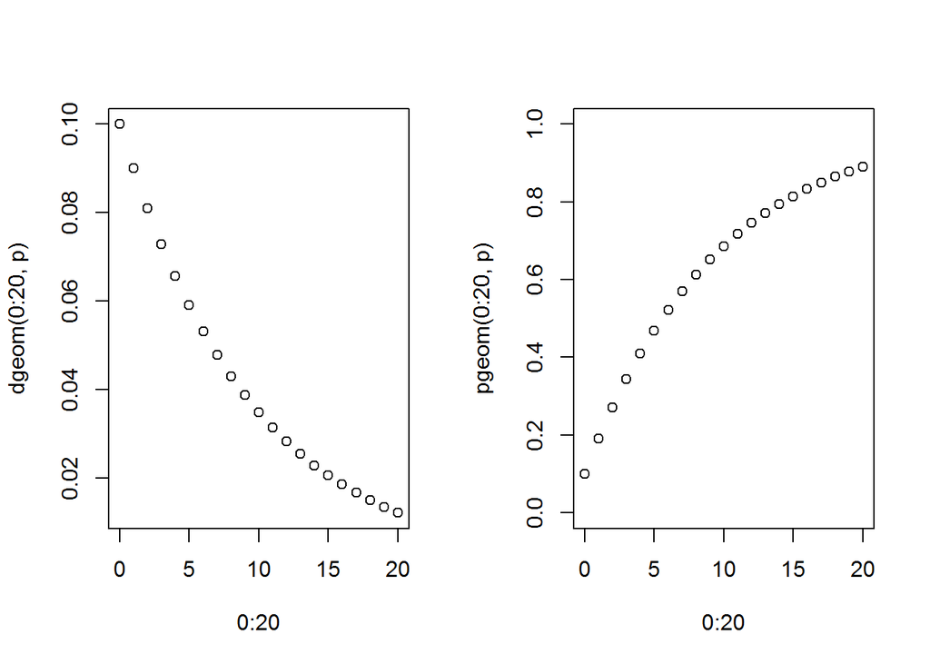

```r
p = 0.1
par(mfrow=c(1,2))
plot(0:20,dgeom(0:20, p)) # Función de densidad
plot(0:20,pgeom(0:20, p), ylim = c(0,1)) # Función distribución
```

```r
qgeom(0.5,p) # Cuantiles
```

```
## [1] 6
```

```r
qgeom(0.75,p)
```

```
## [1] 13
```

```r
rgeom(10, p) # generamos datos aleatorios de esta dist (hasta el éxito)
```

```
##  [1]  1 26 19 19  9  9  2  1  8  3
```

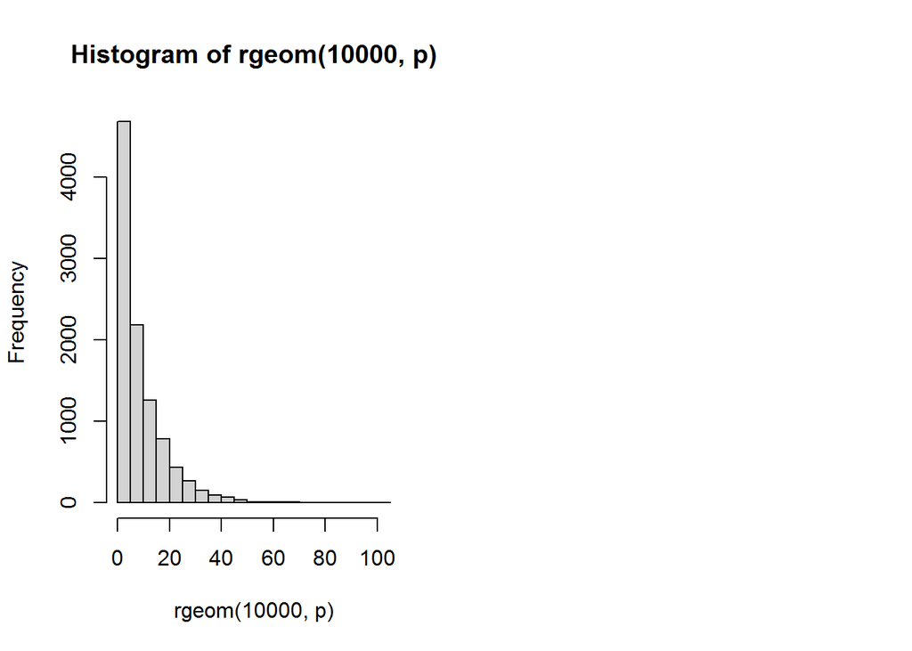

```r
hist(rgeom(10000, p)) # un histograma con 10000 experimentos
```

### Un ejemplo en python

```python
from scipy.stats import geom
import matplotlib.pyplot as plt
import numpy as np

fig, ax = plt.subplots(1,1)
p = 0.3
mean, var, skew, kurt = geom.stats(p, moments='mvsk')

print("Media %f"%mean)
```

```
## Media 3.333333
```

```python
print("Varianza %f"%var)
```

```
## Varianza 7.777778
```

```python
print("Sesgo %f"%skew)
```

```
## Sesgo 2.031889
```

```python
print("Curtosis %f"%kurt)
```

```
## Curtosis 6.128571
```

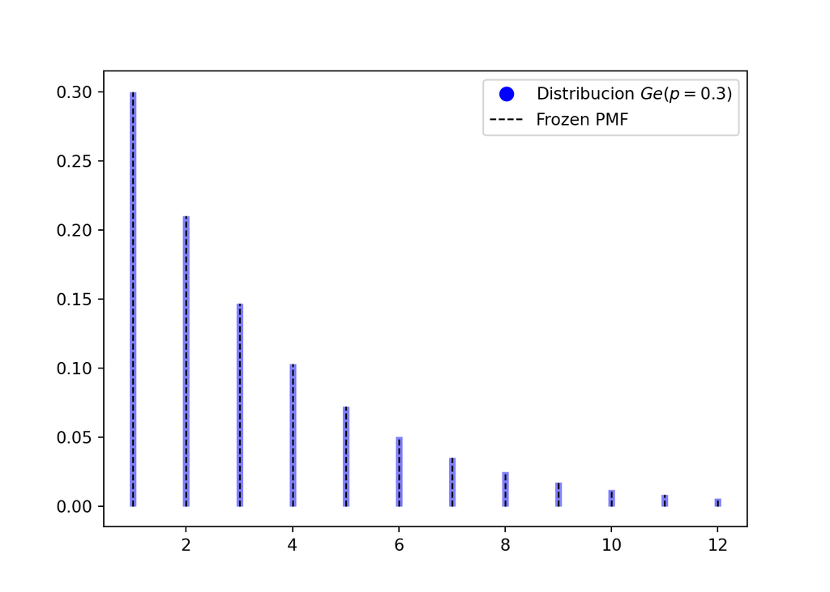

```python
x = np.arange(geom.ppf(0.01,p), geom.ppf(0.99,p))
ax.plot(x,geom.ppf(x,p), 'bo', ms = 8, label = "Distribucion $Ge(p = 0.3)$")
ax.vlines(x,0, geom.pmf(x,p), colors = 'b', lw = 4, alpha = 0.5)



rv = geom(p)
ax.vlines(x,0, geom.pmf(x,p), colors = 'k', linestyles = '--', lw = 1, label = 'Frozen PMF')
ax.legend(loc = 'best')
plt.show()
```

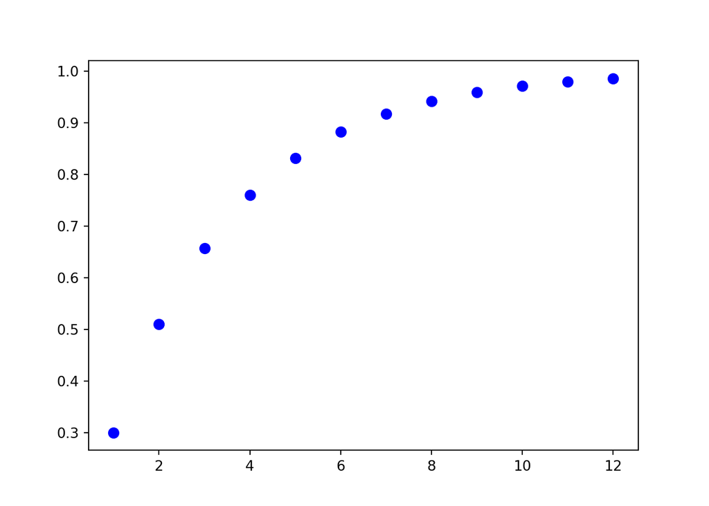

```python
fig, ax = plt.subplots(1,1)
prob = (geom.cdf(x,p))
ax.plot(x, prob, 'bo', ms = 7, label = 'Funcion de distribucion acumulada')
plt.show()
```

```python
fig, ax = plt.subplots(1,1)
r = geom.rvs(p, size = 10000)
plt.hist(r)
```

```
## (array([7.614e+03, 1.572e+03, 6.160e+02, 1.280e+02, 5.300e+01, 1.100e+01,
##        4.000e+00, 1.000e+00, 0.000e+00, 1.000e+00]), array([ 1. ,  4.4,  7.8, 11.2, 14.6, 18. , 21.4, 24.8, 28.2, 31.6, 35. ]), <BarContainer object of 10 artists>)
```

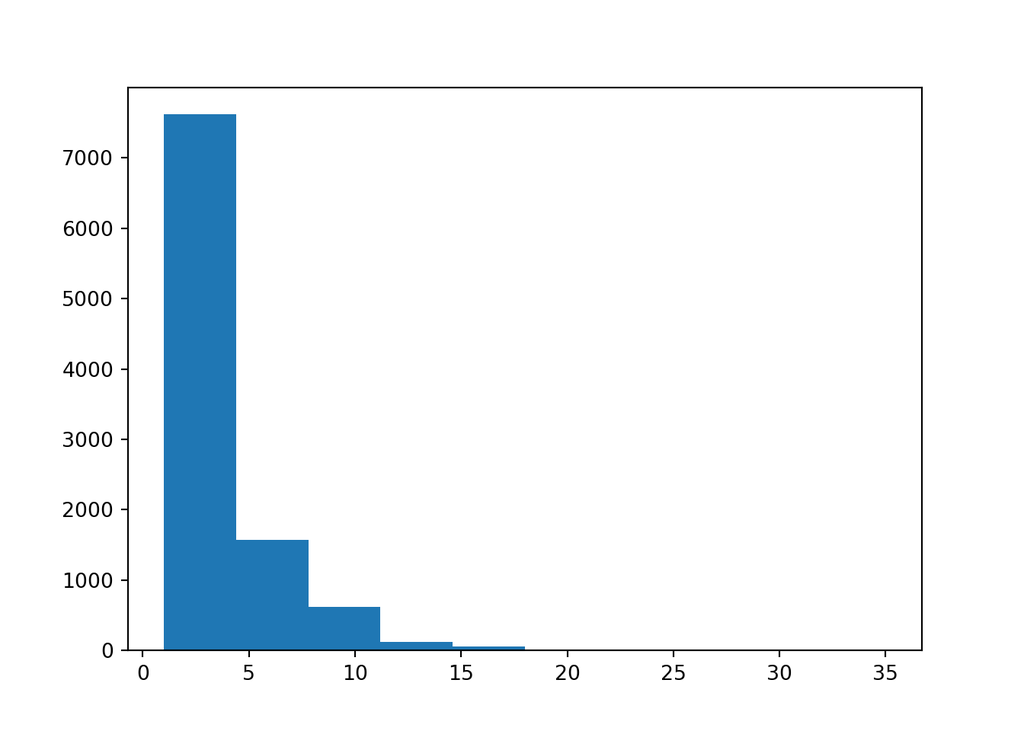

```python
plt.show()
```

## Distribución Hipergeométrica

Consideremos un experimento de extraer, una detrás de otra sin reemplazo, $n$ objetos donde hay $N$ de tipo A y $M$ de tipo B. Si $X$ es una $v.a$ que mide el “el número de objetos del tipo $A$” diremos que $X$ se distribuye como una hipergeométrica con parámeros $N, M y \ n$.

El dominio de $X$ será $D_X = \{0,1,2,...,N\}$

- La *función de densidad* vendrá dado por
  $$f(k)= \frac{{N \choose k}{M \choose{n-k}}}{{N+M \choose n}}$$
- La *función de distribución* viene dada por

$$F(x)=\left\{ \begin{array}{ll}
0 & \mbox{si $x<0$} \\
\sum_{k=0}^x f(x) & \mbox{si $0\le x <n$} \\
1 & \mbox{si $x \ge n$}
\end{array}
\right.$$

Con una *Esperanza* $E(X) = \frac{nN}{N+M}$ y una *Varianza* $Var(X) = \frac{nNM}{(N+M)^2} \cdot \frac{N+M-n}{N+M-1}$

### Un ejemplo de distribución Hipergeométrica en `R`.

Suponga que tenemos 20 animales de los cuales 7 son perros. Queremos medir la probabilidad de encontrar un número determinado de perros si elegimos $k=12$ animales al azar.

```r
# dhyper gives the density, phyper gives the distribution function,
# qhyper gives the quantile function, and rhyper generates random deviates.

x = 12
M = 7
N = 13

dhyper(x = 0:12, m = M, n = N, k = 12)
```

```
##  [1] 0.0001031992 0.0043343653 0.0476780186 0.1986584107 0.3575851393
##  [6] 0.2860681115 0.0953560372 0.0102167183 0.0000000000 0.0000000000
## [11] 0.0000000000 0.0000000000 0.0000000000
```

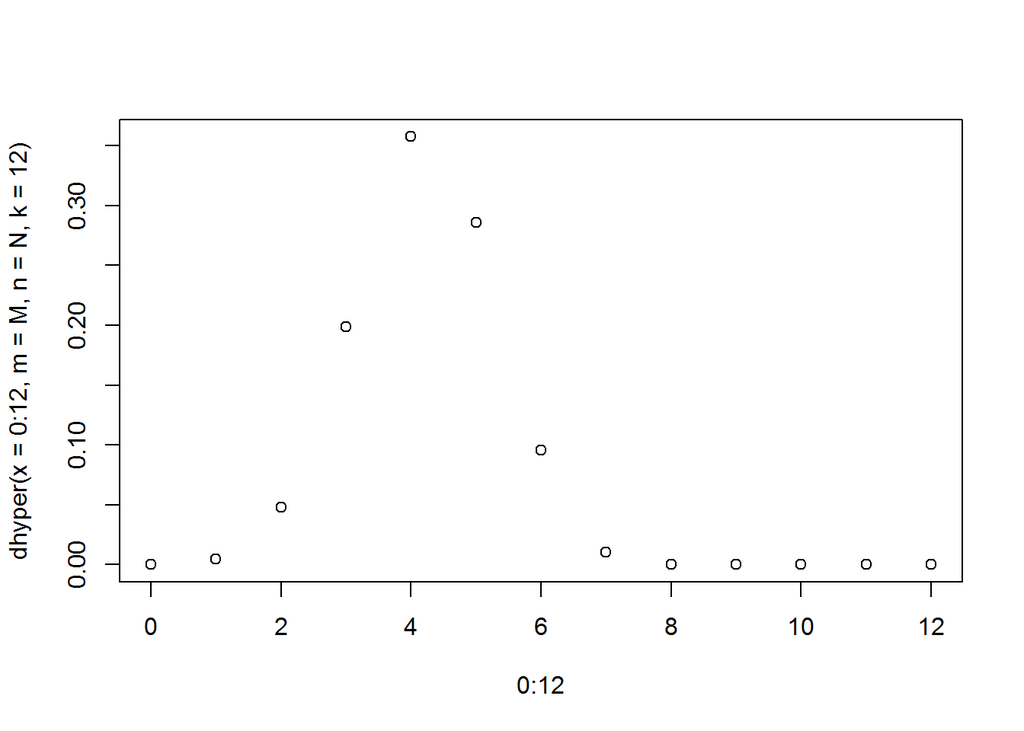

```r
plot(x = 0:12, dhyper(x = 0:12, m = M, n = N, k = 12))
```

```r
phyper(q = 0:12, m =M, n = N, k = 12)
```

```
##  [1] 0.0001031992 0.0044375645 0.0521155831 0.2507739938 0.6083591331
##  [6] 0.8944272446 0.9897832817 1.0000000000 1.0000000000 1.0000000000
## [11] 1.0000000000 1.0000000000 1.0000000000
```

```r
qhyper(p = 0.5, m = M, n = N, k = 12)
```

```
## [1] 4
```

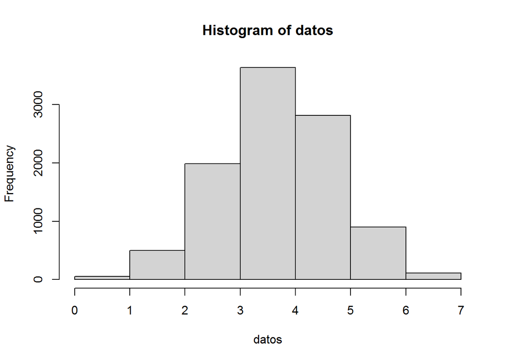

```r
datos <- rhyper(nn = 10000, m = M, n = N,  k=12)

hist(datos, breaks = 8)
```

### Un ejemplo de distribución Hipergeométrica en `Python`.

```python
from scipy.stats import hypergeom
import matplotlib.pyplot as plt
import numpy as np

[M, n, N] = [20,7,12]

rv = hypergeom(M, n, N)
x = np.arange(0, n+1)
y = rv.pmf(x)

mean, var, skew, kurt = rv.stats(moments='mvsk')

print("Media %f"%mean)
```

```
## Media 4.200000
```

```python
print("Varianza %f"%var)
```

```
## Varianza 1.149474
```

```python
print("Sesgo %f"%skew)
```

```
## Sesgo -0.062181
```

```python
print("Curtosis %f"%kurt)
```

```
## Curtosis -0.152661
```

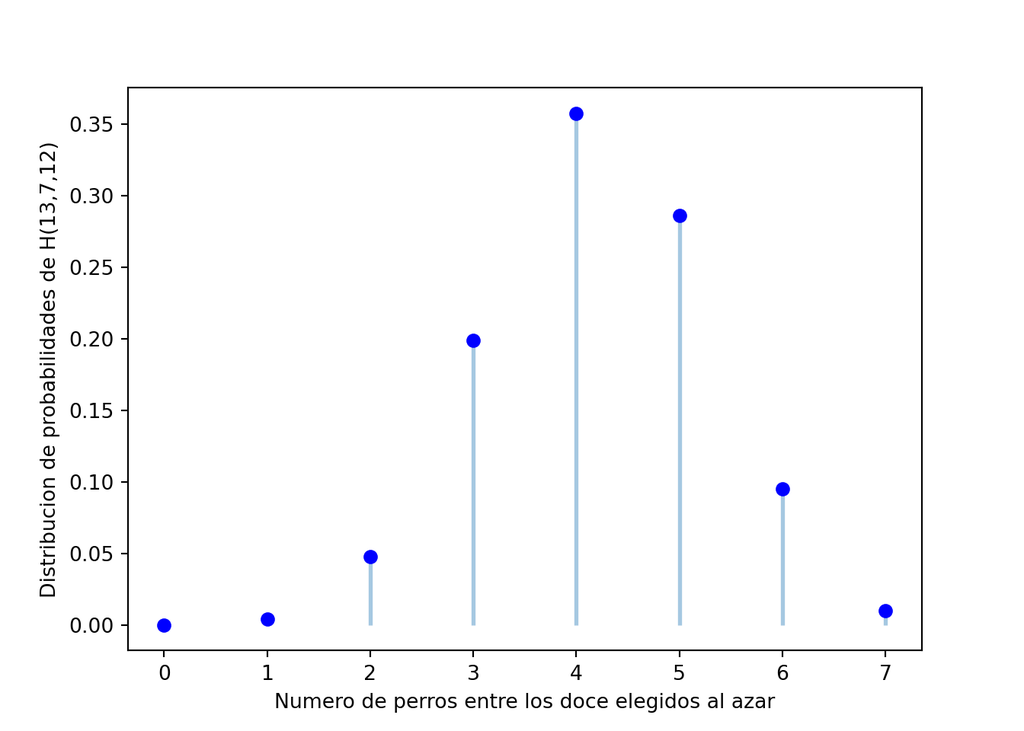

```python
fig = plt.figure()
ax = fig.add_subplot(111)
ax.plot(x,y,'bo')
ax.vlines(x, 0,y, lw =2, alpha = 0.4)
ax.set_ylabel('Distribucion de probabilidades de H(13,7,12)')
ax.set_xlabel('Numero de perros entre los doce elegidos al azar')
plt.show()
```

## Distribución de Poisson

Si $X$ es una $v.a$ que mide el número de eventos en un cierto intervalo de tiempo, diremos que $X$ se distribuye como una Poisson con parámetro $\lambda$
$$X \sim Po(\lambda)$$
donde $\lambda$ representa el número de veces que se espera que ocurra el evento en un intervalo dado.

- El *dominio* de $X$ será $D_X = \{0,1,2,..\}$
- La *función de densidad* viene dada por
  $$f(k) = \frac{e^{-\lambda} \lambda^{k}}{k¡}$$
- La *función de distribución* viene dada por

$$F(x)= \left\{ \begin{array}{ll}
0 & \mbox{si $x<0$} \\
\sum_{k=0}^x f(k) & \mbox{si $0\le x <n$} \\
1 & \mbox{si $x \ge n$}
\end{array}
\right.$$

- La *Esperanza* viene dada por $E(X)= \lambda$ y la varianza $Var(X)= \lambda$

### Un ejemplo de la distribución de Poisson en `R`

Supongamos que $X$ modela el número de errores de edición que tiene una página cuyo valor esperado es $\lambda = 5$.

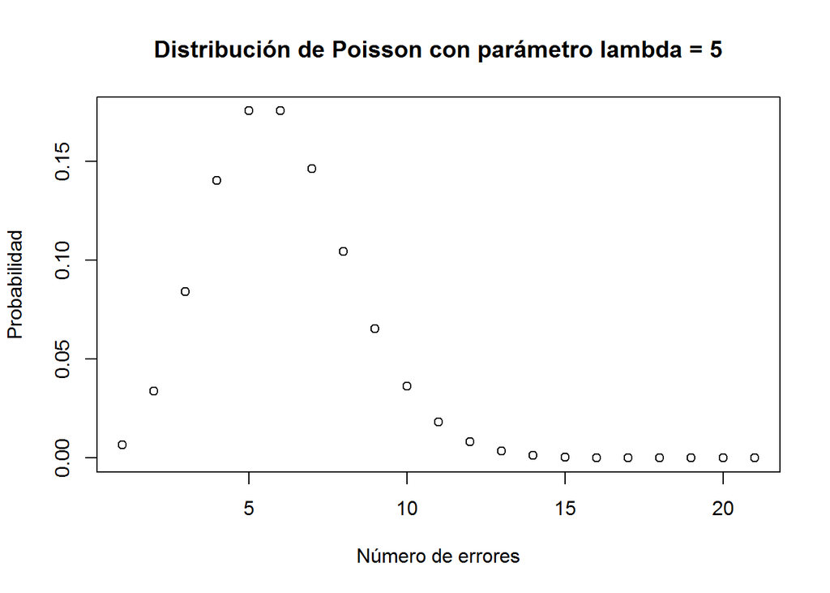

```r
lambda = 5
plot(dpois(x =0:20, lambda = lambda),
     main = 'Distribución de Poisson con parámetro lambda = 5',
     xlab = 'Número de errores',
     ylab = 'Probabilidad')
```

```r
ppois(0:20, lambda = lambda)
```

```
##  [1] 0.006737947 0.040427682 0.124652019 0.265025915 0.440493285 0.615960655
##  [7] 0.762183463 0.866628326 0.931906365 0.968171943 0.986304731 0.994546908
## [13] 0.997981148 0.999302010 0.999773746 0.999930992 0.999980131 0.999994584
## [19] 0.999998598 0.999999655 0.999999919
```

```r
qpois(0.5, lambda = lambda)
```

```
## [1] 5
```

```r
qpois(0.75, lambda = lambda)
```

```
## [1] 6
```

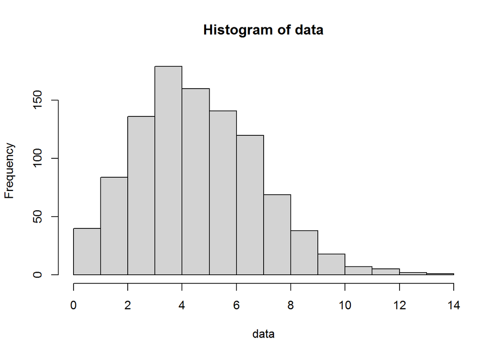

```r
rpois(1000, lambda = lambda) -> data
hist(data)
```

### Un ejemplo de la distribución de Poisson en `Pyhton`

```python
import matplotlib.pyplot as plt
from scipy.stats import poisson
import numpy as np

fig, ax = plt.subplots(1,1)
mu = 5

mean, var, skew, kurt = poisson.stats(mu, moments = "mvsk")
print("Media %f"%mean)
```

```
## Media 5.000000
```

```python
print("Varianza %f"%var)
```

```
## Varianza 5.000000
```

```python
print("Sesgo %f"%skew)
```

```
## Sesgo 0.447214
```

```python
print("Curtosis %f"%kurt)
```

```
## Curtosis 0.200000
```

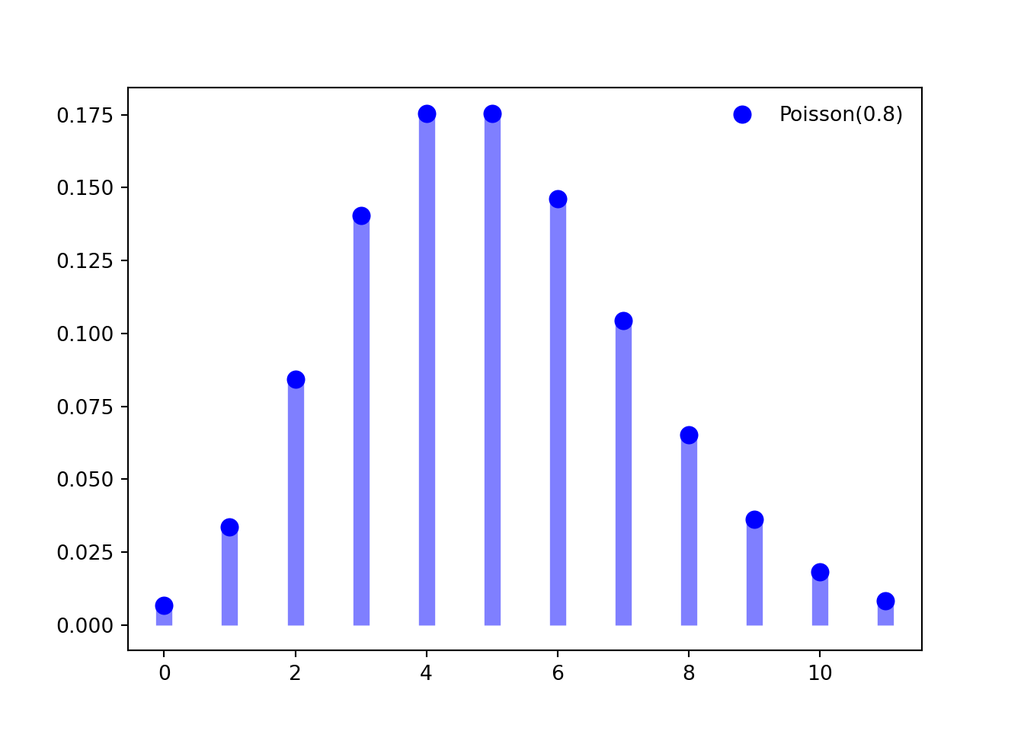

```python
x = np.arange(0, 12)
ax.plot(x, poisson.pmf(x, mu), 'bo', ms = 8, label = 'Poisson(0.8)')
ax.vlines(x,0, poisson.pmf(x, mu), colors = 'b', lw = 8, alpha = 0.5)
ax.legend(loc = 'best', frameon = False)
plt.show()
```

## Distribución Binomial Negativa

Si $X$ es una $v.a$ que mide el número de repeticiones hasta observar los $r$ éxitos en ensayos Bernoulli, diremos que $X$ se distribuye como una Bionomial Negativa con parámetros $r$ y $p$.
$$X \sim BN(r,p)$$
donde $p$ es la probabilidad de éxito.

- El *dominio* de $X$ es $D_X = \{1,2,...\}$
- La *función de densidad* viene dado por $f(k)= {{k-1}\choose{r-1}} p^{r}(1-p)^{k-r}, k\ge r$
- La **FUNCIÓNDE DISTRIBUCIÓN** no tiene una expresión analítica.
- La *Esperanza* es $E(X)=\frac{r}{p}$ y *Varianza* $Var(X) = r\frac{1-p}{p^2}$

### Un ejemplo en `R`.

```r
dnbinom(4, 3, 0.2)
```

```
## [1] 0.049152
```

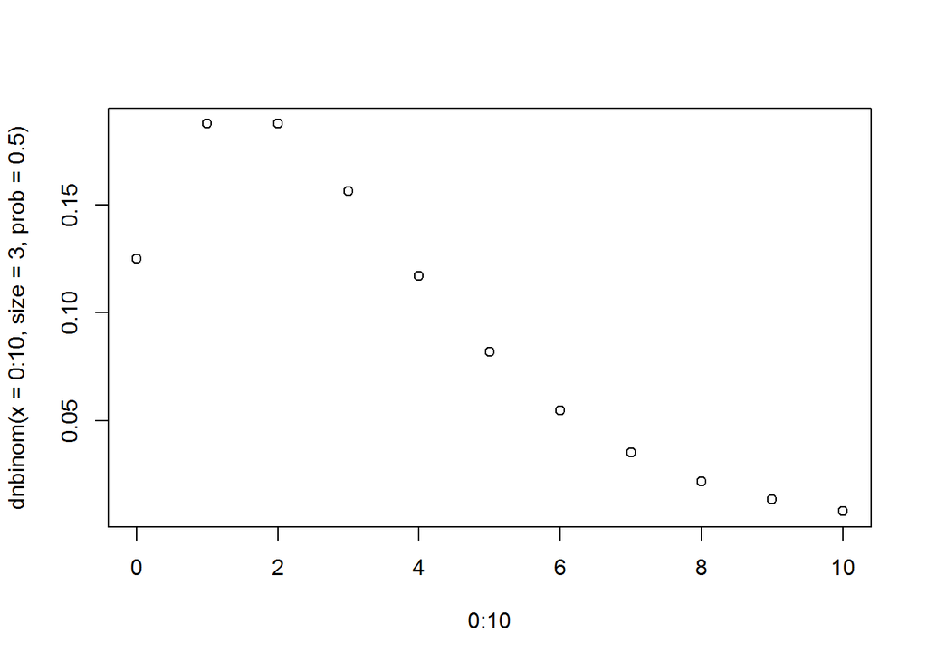

```r
plot(0:10, dnbinom(x = 0:10, size = 3, prob = 0.5))
```

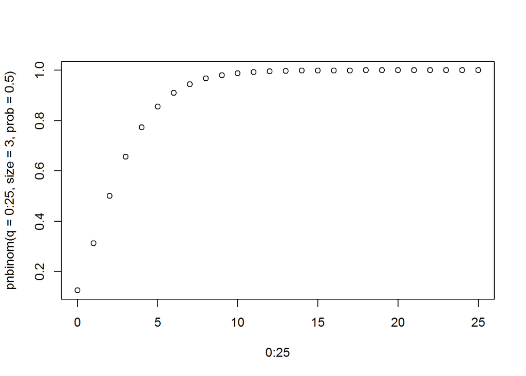

```r
plot(0:25, pnbinom(q = 0:25, size = 3, prob = 0.5))
```

Está función representa la probabilidad de *x fallas previas a r éxitos* cuando la probabilidad de éxito es `prob`.

> This represents the number of failures which occur in a sequence of Bernoulli trials before a target number of successes is reached. The mean is μ = n(1-p)/p and variance n(1-p)/p^2.